# Manejo de datos geográficos mediante R y RStudio

[figure not shown]

## Presentación

Este sitio web contiene los materiales del taller “Manejo de datos geográficos mediante R y RStudio”, el cual es parte de la [II Jornada de Sistemas de Información Geográfica (SIG) y Teledetección (TD) libre de Costa Rica](https://www.geografia.fcs.ucr.ac.cr/index.php/laboratorios/313-ii-jornadas-de-sig-2020), organizada por la [Escuela de Geografía de la Universidad de Costa Rica](https://www.geografia.fcs.ucr.ac.cr/).

El sitio contiene tanto las explicaciones teóricas como el código fuente en R que las ejemplifica y los enlaces a los datos utilizados. Todo los recursos están disponibles en https://github.com/taller-r-jornadas-sigtd-2020.

## ¡Antes de empezar!

Para reproducir los ejemplos en lenguaje R de este taller, primero debe instalar los programas R y RStudio, disponibles en los siguientes enlaces:

- [Instalador de R](https://cloud.r-project.org/). **Nota importante**: a la fecha de escritura de este documento ya está disponible la versión 4 de R. Sin embargo, los ejemplos de este taller se probaron con la [versión 3.6.3 para Windows](https://cran.r-project.org/bin/windows/base/old/3.6.3/R-3.6.3-win.exe).
- [Instalador de RStudio](https://rstudio.com/products/rstudio/download/#download).

**Debe instalarse primero R y luego RStudio**. Si lo desea, puede seguir la guía disponible en [RStudio para Estadística Descriptiva en Ciencias Sociales](https://bookdown.org/gboccardo/manual-ED-UCH/instalacion-de-los-softwares-a-utilizar-en-este-manual.html). También puede consultar [(Tutorial) How to Install R on Windows, Mac OS X, and Ubuntu - DataCamp](https://www.datacamp.com/community/tutorials/installing-R-windows-mac-ubuntu/).

## Introducción

Durante las últimas décadas, las aplicaciones SIG de escritorio (ej. ArcGIS, QGIS) han sido la forma más popular de procesamiento de datos geográficos mediante computadoras. Estas aplicaciones están basadas en una interfaz gráfica a la que el usuario accede mediante menús, botones, íconos y otros elementos similares. A pesar de sus ventajas, entre las que pueden destacarse su facilidad de uso y rápida curva de aprendizaje, los procesos realizados con la interfaz gráfica de un SIG de escritorio son difícilmente reproducibles o repetibles.

Los enfoques basados en interfaces de líneas de comandos ofrecen ventajas mucho mayores en cuanto a reproductibilidad que los basados en interfaces gráficas. Una investigación reproducible es aquella que puede ser realizada de nuevo por personas diferentes a su autor, de manera tal que puedan obtener los resultados originales al seguir la misma metodología. Por lo general, la reproductibilidad requiere que tanto los comandos como los datos utilizados estén disponibles para quienes deseen utilizarlos.

Los comandos se agrupan en programas, también llamados *scripts* en inglés. Por ejemplo, la siguiente secuencia de comandos del lenguaje de programación R carga desde un archivo GeoJSON la capa de cantones de Costa Rica y filtra aquellos con área mayor o igual a 2000 km2:

```r
# Instalación del paquete sf para manejo de datos vectoriales
install.packages("sf")
```

```r
# Carga del paquete sf
library(sf)

# Lectura de la capa de cantones de un archivo GeoJSON
cantones <-
  st_read(
          "https://raw.githubusercontent.com/taller-r-jornadas-sigtd-2020/datos/master/cantones.geojson",
          quiet = T
)

# Filtro de los cantones "grandes" (area >= 2000)
cantones_grandes <- cantones[cantones$area >= 2000, ]
```

Note el uso del símbolo `#` para realizar “comentarios” en el [código fuente](https://es.wikipedia.org/wiki/C%C3%B3digo_fuente) del programa.

El siguiente comando lista los cantones seleccionados:

```r
# Despliegue de los nombres y de las áreas de los cantones grandes
cantones_grandes[, c("canton", "area"), drop = TRUE]
```

```
##          canton    area
## 5  Buenos Aires 2382.94
## 8     Talamanca 2792.23
## 70       Pococí 2408.76
## 71   San Carlos 3352.31
## 74    Sarapiquí 2144.38
```

La función `plot()` despliega un mapa de los cantones seleccionados:

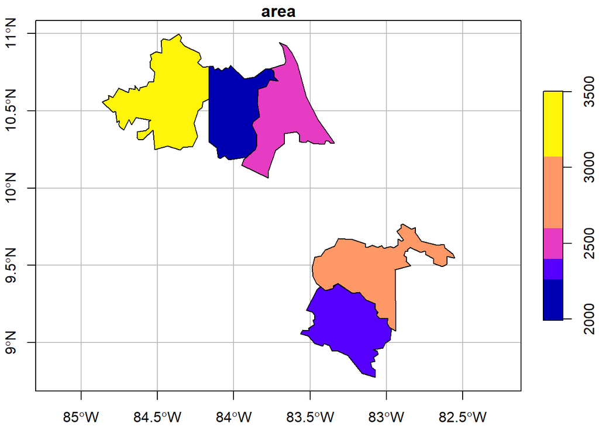

```r
# Mapeo de los cantones grandes
plot(cantones_grandes["area"], axes = TRUE, graticule = TRUE)
```

Otros lenguajes de programación permiten manejar datos geoespaciales de manera similar a R. Entre estos, destaca [Python](https://www.python.org/), un lenguaje de propósito general con un desarrollo muy activo en el área geoespacial. Otros lenguajes de importancia en esta área son JavaScript, para desarrollo en la Web y SQL, para bases de datos.

## El lenguaje de programación R

[R](https://www.r-project.org/) es un lenguaje de programación enfocado en análisis estadístico. Es ampliamente utilizado en diversas áreas de investigación, entre las que pueden mencionarse [aprendizaje automático (*machine learning*)](https://en.wikipedia.org/wiki/Machine_learning), [ciencia de datos](https://en.wikipedia.org/wiki/Data_science) y [*big data*](https://en.wikipedia.org/wiki/Big_data), con aplicaciones en campos como biomedicina, bioinformática y finanzas, entre muchos otros. Fue creado por Ross Ihaka y Robert Gentleman en la Universidad de Auckland, Nueva Zelanda, en 1993.

Algunas de las principales características de este lenguaje son:

- Es interpretado: las instrucciones se traducen una por una a [lenguaje máquina](https://en.wikipedia.org/wiki/Machine_code), a diferencia de los [lenguajes compilados](https://en.wikipedia.org/wiki/Compiler), que traducen de manera conjunta las instrucciones de una unidad completa (ej. un programa o una biblioteca). Los lenguajes interpretados tienden a ser más lentos que los compilados, pero también son más flexibles.
- Es [multiplataforma](https://en.wikipedia.org/wiki/Cross-platform_software): puede ejecutarse en los sistemas operativos más populares (ej. Microsoft Windows, macOS, Linux).
- Tiene un [sistema de tipos de datos dinámico](https://pythonconquerstheuniverse.wordpress.com/2009/10/03/static-vs-dynamic-typing-of-programming-languages/): las variables pueden tomar diferentes tipos de datos (ej. textuales, numéricos) durante la ejecución del programa, a diferencia del caso de un sistema de tipos de datos estático, en el que las variables solo pueden tener un tipo de datos.
- Soporta varios [paradigmas de programación](https://en.wikipedia.org/wiki/Programming_paradigm): los paradigmas son estilos o enfoques teóricos de programación. R soporta los paradigmas de [programación orientada a objetos](https://en.wikipedia.org/wiki/Object-oriented_programming), [programación imperativa](https://en.wikipedia.org/wiki/Imperative_programming), [programación funcional](https://en.wikipedia.org/wiki/Functional_programming) y [programación procedimental](https://en.wikipedia.org/wiki/Procedural_programming).

R es un proyecto de [software libre](https://en.wikipedia.org/wiki/Free_software) que se comparte mediante una licencia [GNU General Public Licence (GNU GPL)](https://www.gnu.org/licenses/old-licenses/gpl-2.0.html). Esta característica permite que la funcionalidad original de R pueda ser ampliada mediante bibliotecas o paquetes desarrollados por la comunidad de programadores.

### Sintaxis

#### Funciones, bibliotecas y paquetes

R, al igual que otros lenguajes de programación, estructura su funcionalidad por medio de segmentos de código llamados funciones. Cada función realiza una tarea específica como, por ejemplo, un cálculo matemático. Todas las funciones tienen un nombre y un conjunto de parámetros que especifican los datos de entrada que procesa la función. Los parámetros se escriben entre paréntesis redondos (`()`) y estos siempre deben incluirse, aún en el caso de que la función no tenga ningún parámetro. Si la función tiene varios parámetros, deben separarse mediante comas (`,`).

Por ejemplo, la función `print()` recibe como parámetro un valor (ej. un texto o un número) para imprimirlo en la pantalla. En el siguiente fragmento de código en R, se utiliza `print()` para imprimir la hilera [“Hola mundo”](https://en.wikipedia.org/wiki/%22Hello,_World!%22_program).

```r
# Impresión de una hilera de carácteres
print("Hola mundo")
```

```
## [1] "Hola mundo"
```

La función `mean()` retorna la media aritmética del parámetro de entrada. En el siguiente ejemplo, se calcula la media de los números de un vector creado a su vez con la función `c()`.

```r
# Media aritmética
mean(c(2, 4, 5, 9))
```

```
## [1] 5
```

La función `getwd()` (*get working directory*) retorna la ruta del directorio de trabajo de la sesión actual de R. Este es el directorio en el cual R espera encontrar, por ejemplo, archivos de datos.

```r
# Consultar directorio de trabajo
getwd()
```

```
## [1] "C:/Users/mfvargas/taller-r-jornadas-sigtd-2020/taller-r-jornadas-sigtd-2020.github.io"
```

La función `setwd()` (*set working directory*) establece la ruta del directorio de trabajo de la sesión actual de R. Como parámetro, recibe una hilera de texto con la ruta.

```r
# Establecer directorio de trabajo (la ruta debe existir)
setwd("c:/users/mfvargas")
```

Los parámetros de las funciones tienen nombres que pueden especificarse en caso de ser necesario. En el siguiente ejemplo, se utilizan los nombres de los parámetros `x`, `xlab` y `ylab` de la función `plot()` para especificar la fuente de datos y las etiquetas de los ejes x e y de un gráfico.

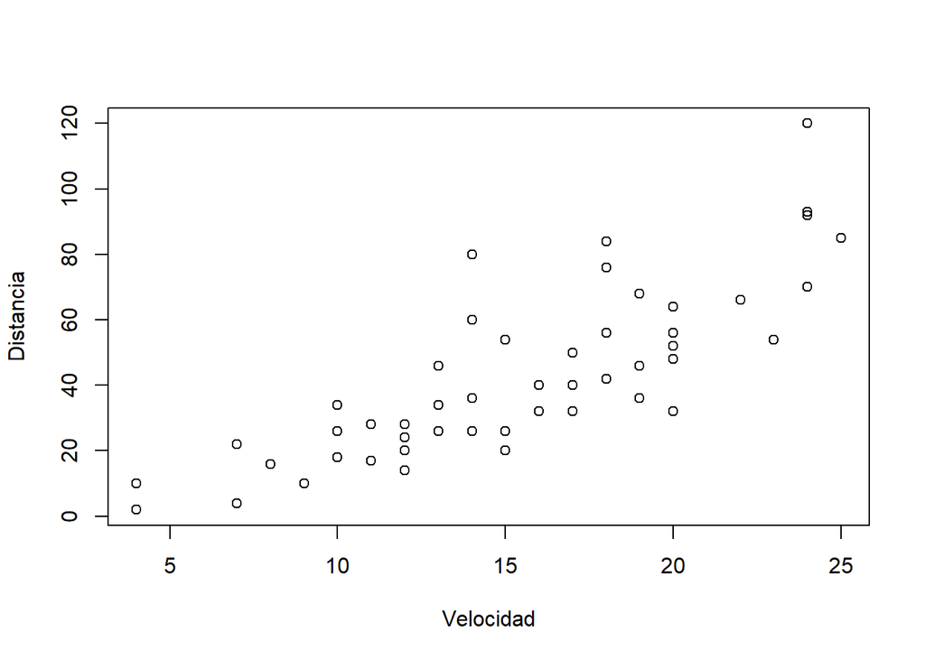

```r
# Gráfico con etiquetas en los ejes x e y
plot(
  x=cars,
  xlab="Velocidad",
  ylab="Distancia"
)
```

**Nota**: para efectos de pruebas y ejemplos, el interpretador de R incorpora varios conjuntos de datos en la forma de data frames que pueden listarse con la función `data()`. Para consultar un conjunto en particular, puede utilizarse el operador `?` desde la línea de comandos de R (ej. `?cars`).

Para obtener ayuda de una función desde la línea de comandos de R, puede utilizarse un signo de pregunta (`?`) seguido del nombre de la función. Por ejemplo:

```r
# Ayuda de la función setwd()
?setwd
```

También puede obtenerse ayuda sobre una función en los buscadores de Internet (ej. Google), además de ejemplos y otros materiales de apoyo.

Las funciones de R se agrupan en conjuntos llamados bibliotecas, las cuales se distribuyen en [paquetes](https://cran.r-project.org/web/packages/available_packages_by_name.html). Para utilizar un paquete, este debe instalarse primero con la función `install.packages()` y luego cargarse con la función `library()`.

```r
# Instalación del paquete sf (note las comillas)
install.packages("rgdal")
```

```r
# Carga del paquete sf
library(rgdal)
```

#### Tipos de datos, objetos y variables

R puede trabajar con varios tipos de datos, entre los que están números, carácteres (i.e. textos) y *booleanos* (o lógicos). También utiliza tipos más complejos, como vectores y matrices.

Como se mencionó anteriormente, R es un lenguaje de programación orientado a objetos. Un objeto es una entidad que tiene asociadas propiedades y métodos para manipular esas propiedades. Un objeto puede ser, por ejemplo, un número, un texto, un vector o una matriz.

Hay muchas formas de crear objetos en R. Una de las más sencillas es con los operadores de asignación. Estos son `=` y `<-`. Las siguientes sentencias crean un número, un texto y un vector.

```r
# Número
x <- 10
# Hilera de carácteres
nombre <- 'Manuel'
# Vector de hileras de carácteres
dias <- c('Domingo', 'Lunes', 'Martes', 'Miércoles', 'Jueves', 'Viernes', 'Sábado')
```

Tanto `x`, como `nombre` como `dias` son variables. Una variable es una etiqueta que se le asigna a un valor (o a un objeto). Una variable tiene un nombre que debe comenzar con una letra.

El tipo de una variable (u objeto) puede consultarse con la función `typeof()`. Por ejemplo:

```r
print(typeof(x))
```

```
## [1] "double"
```

```r
print(typeof(nombre))
```

```
## [1] "character"
```

A continuación, se describen con más detalle algunos de los tipos de datos utilizados en el lenguaje R.

##### Números

Pueden ser enteros o fracciones. Se utilizan en operaciones aritméticas (ej. suma, resta, multiplicación, división).

```r
# Números enteros
x <- 10
y <- 20
# Suma
print(x + y)
```

```
## [1] 30
```

```r
# Números decimales
x <- 0.5
y <- 3.14
# Multiplicación
print(x * y)
```

```
## [1] 1.57
```

##### Carácteres

Se utilizan para representar textos. Deben estar encerrados entre comillas simples `'`o dobles `"`.

```r
# Hileras de carácteres
nombre <- "María"
apellido <- "Pérez"
# Concatenación
print(paste(nombre, apellido))
```

```
## [1] "María Pérez"
```

##### Booleanos

Los objetos *booleanos* (también llamados lógicos) tienen dos posibles valores: verdadero (`TRUE`) o falso (`FALSE`).

```r
# Variable booleana
b = 1 < 2
print(b)
```

```
## [1] TRUE
```

```r
# Variable booleana
c = 1 > 2
print(c)
```

```
## [1] FALSE
```

Las expresiones booleanas pueden combinarse con operadores como:

- `&` (Y, en inglés *AND*)
- `|` (O, en inglés *OR*)
- `!` (NO, en inglés *NOT*)

```r
# Operador lógico AND
print((1 < 2) & (3 < 4))
```

```
## [1] TRUE
```

```r
# Operador lógico OR
print((2 + 2 == 5) | (20 <= 10))
```

```
## [1] FALSE
```

```r
# Operador lógico NOT
print(!(2 + 2 == 5))
```

```
## [1] TRUE
```

##### Vectores

Un vector es una estructura de una dimensión que combina objetos del mismo tipo. Se crean con la función `c()` (del inglés *combine*), como en los siguientes ejemplos:

```r
# Definición de un vector de números
a = c(1, 2, 3, 4, 5)
print(a)
```

```
## [1] 1 2 3 4 5
```

```r
# Definición de un vector de hileras de carácteres
b = c("Álvaro", "Ana", "Berta", "Bernardo")
print(b)
```

```
## [1] "Álvaro"   "Ana"      "Berta"    "Bernardo"
```

##### Data Frames

Los *data frames* son estructuras bidimensionales compuestas por varios vectores, de manera similar a una matriz. Cada vector corresponde una columna de la matriz.

La función `data.frame()` puede utilizarse para crear un data frame a partir de vectores que serán las columnas del data frame.

```r
# Vector de nombres de países
paises = c("PAN", "CRI", "NIC", "SLV", "HND", "GTM", "BLZ", "DOM")
# Vector de cantidades de habitantes (en millones)
poblaciones = c(4.1, 5.0, 6.2, 6.4, 9.2, 16.9, 0.3, 10.6)
# Creación de un data frame a partir de los dos vectores
ca_poblacion_paises = data.frame(
                        pais = paises,
                        poblacion = poblaciones
                      )
print(ca_poblacion_paises)
```

```
##   pais poblacion
## 1  PAN       4.1
## 2  CRI       5.0
## 3  NIC       6.2
## 4  SLV       6.4
## 5  HND       9.2
## 6  GTM      16.9
## 7  BLZ       0.3
## 8  DOM      10.6
```

La función `summary()` proporciona un resumen de los contenidos de un data frame:

```r
# Resumen de los contenidos del data frame
print(summary(ca_poblacion_paises))
```

```
##       pais     poblacion
##  BLZ    :1   Min.   : 0.300
##  CRI    :1   1st Qu.: 4.775
##  DOM    :1   Median : 6.300
##  GTM    :1   Mean   : 7.338
##  HND    :1   3rd Qu.: 9.550
##  NIC    :1   Max.   :16.900
##  (Other):2
```

#### Importación de datos

Por lo general, los datos con los que se trabaja en R provienen de fuentes externas, como archivos de texto, [bases de datos](https://en.wikipedia.org/wiki/Database) o [servicios web](https://en.wikipedia.org/wiki/Web_service). A continuación, se estudiarán funciones que permiten importar datos desde algunas de estas fuentes.

##### La función read.csv()

La función `read.csv()` importa datos desde un archivo de valores separados por comas (CSV, *comma separated values*) y los almacena en un data frame. Como parámetro, recibe la ruta del archivo. Si la ruta no es absoluta, se toma como relativa al directorio actual de trabajo.

En el siguiente ejemplo, se usa la función `read.csv()` para importar los datos de casos de COVID-19 en Costa Rica. Los datos usados en este ejemplo están basados en los publicados por el [Ministerio de Salud de Costa Rica](http://geovision.uned.ac.cr/oges/).

```r
# Importación de casos de COVID-19 en Costa Rica
covid19_general <- read.csv("https://raw.githubusercontent.com/taller-r-jornadas-sigtd-2020/datos/master/covid19-general-20200709.csv")

# Despliegue de los últimos registros
covid19_general[120:126,
                c("FECHA", "positivos", "activos", "RECUPERADOS", "fallecidos")
                ]
```

```
##          FECHA positivos activos RECUPERADOS fallecidos
## 120 03/07/2020      4311    2636        1657         18
## 121 04/07/2020      4621    2882        1721         18
## 122 05/07/2020      4996    3232        1745         19
## 123 06/07/2020      5241    3452        1766         23
## 124 07/07/2020      5486    3653        1810         23
## 125 08/07/2020      5836    3883        1929         24
## 126 09/07/2020      6485    4437        2023         25
```

## El ecosistema geoespacial de R

## Recursos recomendados

### R y RStudio

- Sitio web del lenguaje de programación R: [The R Project for Statistical Computing](https://www.r-project.org/)
- Sitio web del entorno de desarrollo RStudio: [RStudio | Open source & professional software for data science teams](https://rstudio.com/)

### Paquetes de R

- Sitio web del paquete sf de R: [Simple Features for R - sf](https://r-spatial.github.io/sf/)
- Sitio web del paquete raster de R: [Raster data manipulation - R](https://rspatial.org/raster/spatial/8-rastermanip.html)
- Sitio web del paquete flexdashboard de R: [flexdashboard: Easy interactive dashboards for R](https://rmarkdown.rstudio.com/flexdashboard/)
- Sitio web del paquete Leaflet para R: [Leaflet for R](https://rstudio.github.io/leaflet/)
- Sitio web del paquete Plotly para R: [Plotly R Open Source Graphing Library](https://plotly.com/r/)
- Sitio web del paquete DT para R: [DT: An R interface to the DataTables library](https://rstudio.github.io/DT/)

### Git

- Sitio web del sistema Git para control de versiones: [Git](https://git-scm.com/)

### Libros

- Libro “Geocomputation with R”, de Lovelace et al.: [Geocomputation with R](https://geocompr.robinlovelace.net/)
- Libro “R Markdown: The Definitive Guide”, de Xie et al.: [R Markdown: The Definitive Guide](https://bookdown.org/yihui/rmarkdown/)